# Semantic Annotation Overview

On this file I will report an exploratory analysis of the semantic annotation data on 34 Dutch lexical items. First I will describe how the tokens were distributed and them the levels of agreement we encounter in the data. These are overall observations, and there is much more to see at the level of the type and the token. A main takeaway is that, while some annotations are not that trustworthy indeed, in the big scale it seems to even out enough to go further into superficial analyses of different aspects. I did not find compelling reasons to discard someone’s annotations yet.

# Basic numbers

The dataset comprises annotations of 34 types: 13 adjectives, 13 verbs and 8 nouns. For each type, we have 240-360 tokens (randomly selected from different files) annotated by 3-4 annotators. The tokens were divided in 6-9 batches of 40 tokens; the number of batches depends on the number of distinct senses distinguished for the type and the skewness of their distribution in a sample of 40-50 tokens analyzed by me. Their distribution is shown in Table 1.

Table 1. Analyzed types and their number of batches and definitions

| adjs | batches | defs | nouns | batches | defs | verbs | batches | defs |
| --- | --- | --- | --- | --- | --- | --- | --- | --- |
| heilzaam, hachelijk, hoopvol, hemels, geldig | 6 | 2 | spot | 6 | 3 | herroepen, heffen, huldigen, haten | 6 | 2 |
| geestig | 7 | 2 | horde | 7 | 3 | herinneren, diskwalificeren, helpen, herstructureren | 6 | 3 |
| hoekig, gekleurd | 7 | 3 | blik | 7 | 6 | herstellen | 6 | 5 |
| dof, goedkoop | 8 | 4 | hoop | 8 | 3 | herhalen | 8 | 3 |
| gemeen | 8 | 5 | staal | 8 | 4 | herkennen | 8 | 4 |
| grijs | 8 | 6 | stof | 8 | 5 | harden | 8 | 5 |
| heet | 9 | 6 | schaal | 8 | 6 | haken | 9 | 5 |
|  |  |  | spoor | 9 | 8 |  |  |  |

The tokens were annotated by 48 annotators, 14 of which annotated two shifts. A shift involves a set of 12 batches of different types (at least 3 nouns, 4 adjectives and 4 verbs); a double shift may involve a different proportion, but tried to minimize the number of batches per type.

While the main variable we will be looking at now is the sense, the annotators also provided a confidence for the annotation. However, we don’t know if they all understood or assessed their own confidence in the same way. The distribution of confidence assignments illustrated in Figure 1 is quite unequal; there is more consistency between shifts of the same annotator than between annotators within each shift.

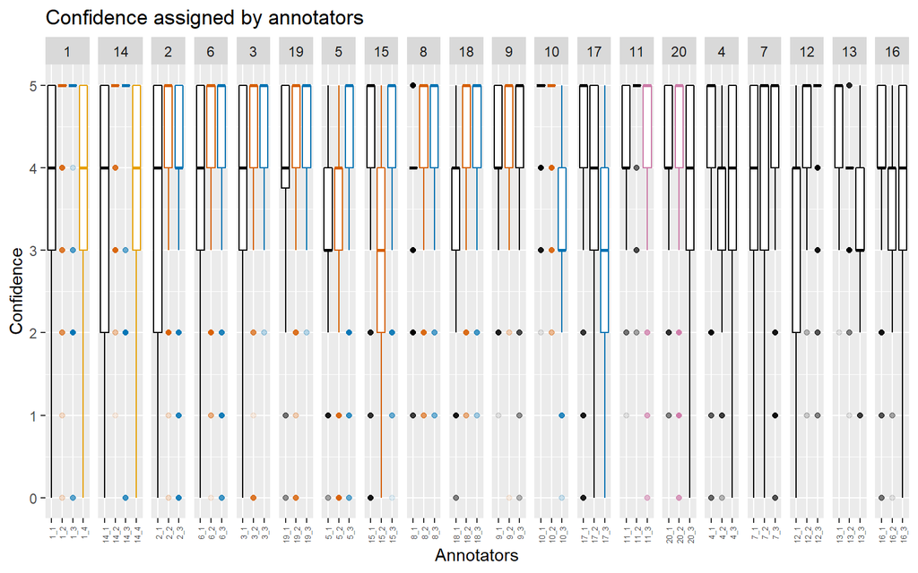

Figure 1. Distribution of confidence values assigned by each annotator. Unless they are black, boxplots of the same color in two consecutive facets indicate the same annotator.

# Agreement

Figure 2 illustrates the proportion of agreement per annotator per shift, while Figure 3 does so per annotator.

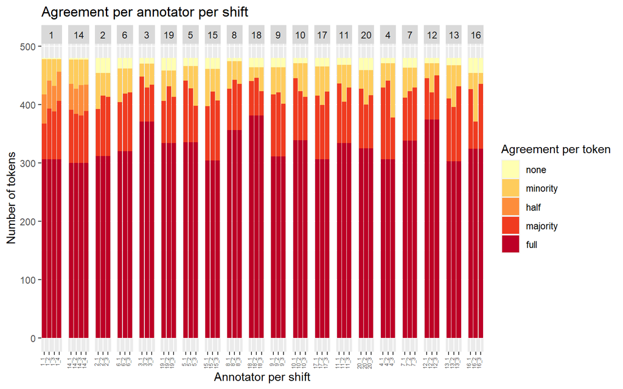

Figure 2. Agreement per annotator per shift

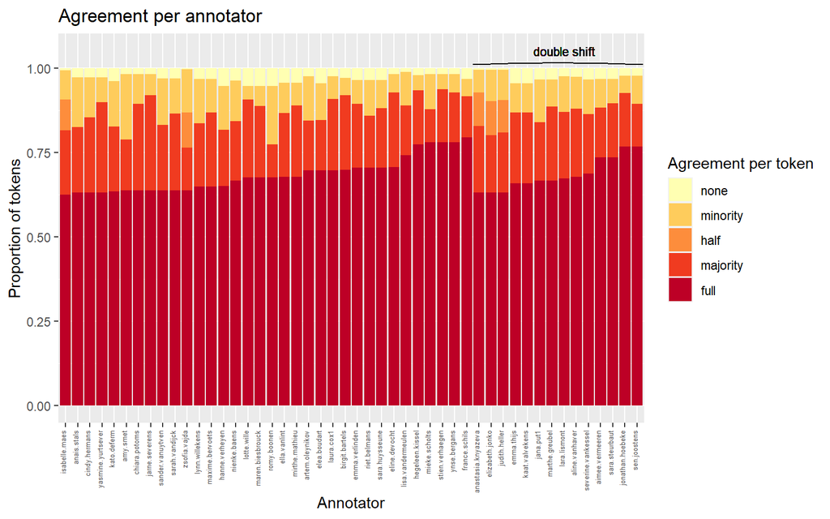

Figure 3. Agreement per annotator

Figure 4 shows the number of tokens with a certain agreement per type. The text next to the lines indicates the number of tokens annotated per type.

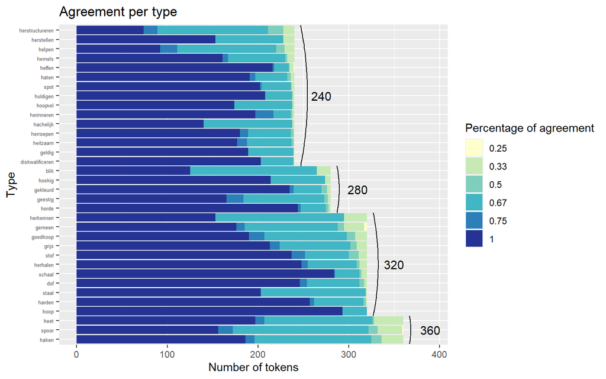

Figure 4. Agreement per type, sorted by number of tokens without agreement within frequency of type.

Finally, Figure 5 shows, for each token-annotation pair, the correlation between agreement and confidence. Each dot in this plot represents a token-annotation pair (e.g. for each token, there are 3-4 dots, representing the annotations made on it); the x-axis shows the agreement of the annotation with other annotations of that token, and the y-axis the confidence of that assignment. We can see that there is a number of annotators that assign a majority sense while giving a low confidence, and an even higher number of disagreeing annotations with a high confidence. These phenomena could be due to particular tendencies of the types, annotators or senses involved and will be looked into later.

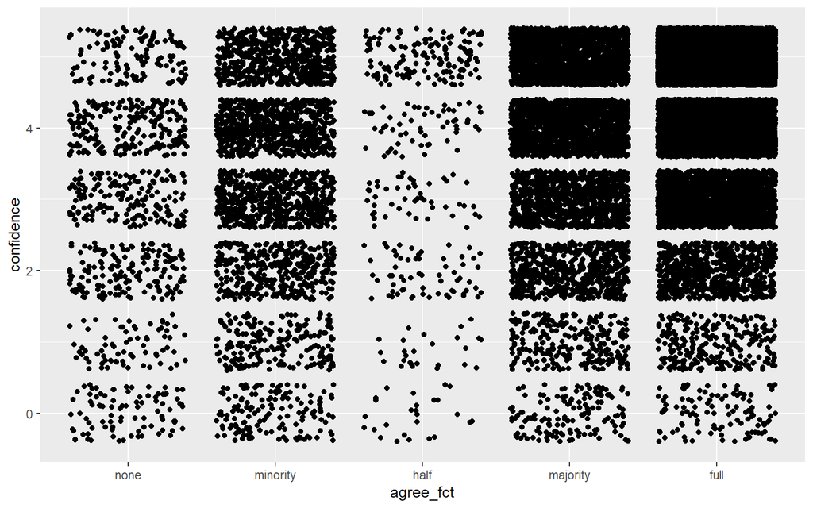

# Type by type: sense confusions, confidences and clouds

I will treat type-by-type analyses in different files. For now, nouns.html reports on my analyses of the nouns. Since it’s a thinking process and I’m learning how to look at the data as I go, there is a lot of redundant or trivial information. For each type, I give a small explanation of the definitions, the expectations and reality on the sense distribution (which I would consider a factor when comparing the performance of the workflow), “confusion matrices” of the annotations and an initial description of the clouds. I have not touched the cues yet.

The [visualization](http://montesmariana.github.io/NephoVis/) currently (as of 2020-03-12) supports three levels. On level one we can look at an MDS solution of a distance matrix based on procrustes analysis of the distance matrices of the models of a type. The plot can be color- shape- and size coded based on the parameters that characterize the model plus some other features, and the values of such parameters can also be used to select models. Level 2 lets us see the 2D representations of the selected models (up to 9). If available (for now, all types have it) it is possible to switch between MDS and t-SNE solutions, the latter with different perplexity values. It’s possible to color-, shape- and size-code the plots with values from the annotation and see the concordance by hovering over the dots. It is also possible to color-code *the models* based on some parameter, for easier comparisons. Selecting a dot or group of dots highlights them in all plots. Level 3 is the single-cloud level, with similar functionalities plus the option of accessing highlighted contexts (emphasizing the context words selected by the model, and eventually the cues selected by the annotators) and selecting tokens by the context words that were picked up by the model or are present in the context. In all levels it’s possible to select a group of tokens by clicking on the corresponding parameter value on a legend, if they are coded.

Mariana Montes

2020-03-12